# project_2

Jessica Chen

2022-11-21

### Abstract:

Environmental factors are always considered to be contributing to species’ living habits.In this project, we are specifically interested in how environmental variables affect the number of species present in the locations. Specifically, we are going to study three species - gazelleThomsons, topi and zebra.

The data set we used comes from a long-term research program run by Wake Forest University in the Serengeti Park in Tanzania. The data image was collected from cameras installed at 19 different sites in the Serengeti. We are only going to use the subset of this data. In the report, we performed analysis on every potential variables in the data, and fitted the models which can explain statistically how environmental variables affect the counts of species. We then compared the results of each species. It turned out that the count of species has different relationships with our predicted environmental variables.

### Section1: Introduction

We are interested in the question: Is there a relationship between the environmental variables and the counts for each species? The data we used comes from the research program run by Wake Forest University in the Serengeti Park in Tanzania. The data image was collected from cameras installed at 19 different sites in the Serengeti.

To answer the research question, we use visualizations and zero inflated poisson models to explore the relationship between the counts of three species and different environmental factors such as risk to lion predation and distance to the nearest river..etc. We find that, the counts of the species are related to environmental factors, and also different environmental factors have different impacts on different species.

### Section2 Data

### Part1: Data Preparation

There are overall 966 rows and 15 columns in the serengeti dataset, which means that there are 966 independent observations. The observations are taken in 19 different sites in Serengeti in different 8-day time periods. Specifically, each observation contain 15 key informations: siteID, date, site.date, ndvi,gazelleThomsons.count,gazelleThomsons.present, topi.count, topi.present, zebra.count, zebra.present, fire, amRiDist, TM100, LriskDry, which corresponds to 15 column variables in the datatable.

To help with further analysis, we will specify the meaning of each 9 variables in the data set. There are three continuous numerical data: ‘ndvi’ is a measure of how “green” the location is. Locations have high values of ndvi if they have a lot of vegetation, or if the vegetation is of high quality and very green. We may refer to the situation as “greenness” in the later text. And ‘amRivDist’ is the distance from the location to the nearest river. ‘LriskDry’ is a measure of how risky the location is to lion predation.

And there are overall 5 discrete numerical variables in the dataset. ‘gazelleThomsons.count’ refers to the count of Thomson’s gazelles that were spotted over the 8-day period. ‘topi.count’ refers to the count of topi that were spotted over the 8-day period. ‘zebra.count’ refers to the count of zebras that were spotted over the 8-day period. ‘TM100’ counts the number of termite mounds within 100 meters of the location. ‘T50’ counts the number of trees within 50 meters of the location.

And there is one binary response variables exist in the dataset: ‘fire’ refers to the presence of a detected wildfire in the 30 days preceding the time period.And Termite mounds are an indicator of soil quality.

### Part2: EDA

#### a. EDA on three response variables: gazelleThomsons.count, topi.count,zebra.count

gazelleThomsons.count, topi.count and zebra.count are count data, so we can draw a histogram of each to visualize its distribution. From Figure2.1, Figure2.2, and Figure3, we can see that there are excess of zero count in the distribution.We want to model these excess zeros independently so our model can be a better fit. We may use zero inflated Poisson model later to investigate the relationship between the species count and the environmental factors.

#### Figure 2.1 : gazelleThomsons.count

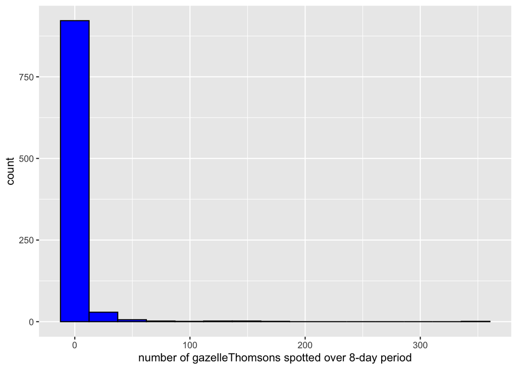

Figure 2.1: Histogram of the number of gazelleThomsons spotted over the 8-day period

#### Figure 2.2 : topi.count

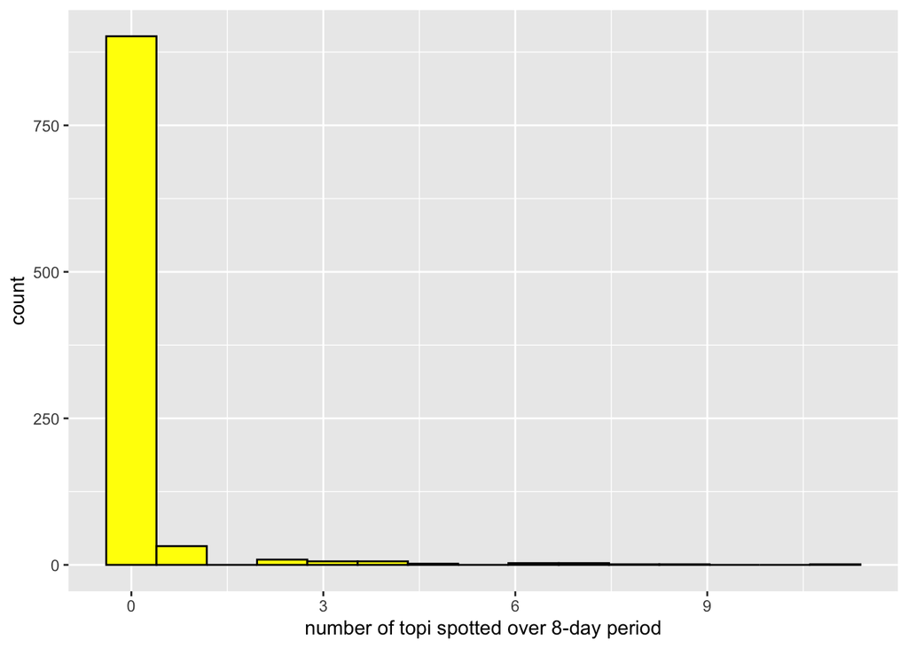

Figure 2.2: Histogram of the number of topi spotted over the 8-day period

#### Figure 2.3 : zebra.count

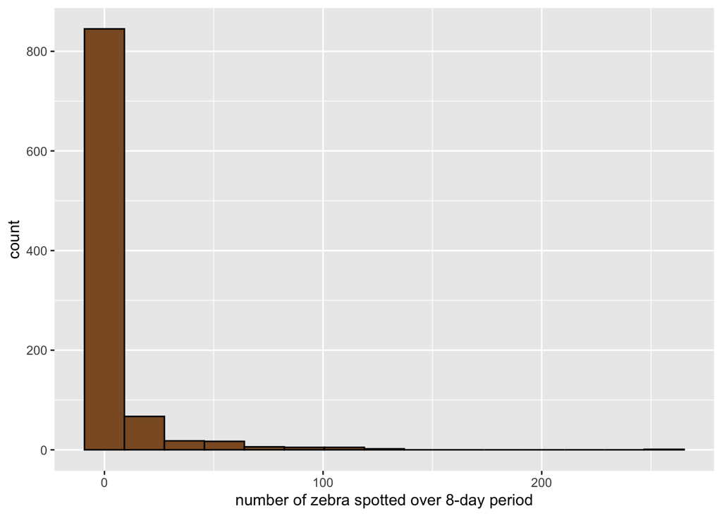

Figure 2.3: Histogram of the number of zebra spotted over the 8-day period

#### b. EDA on bivariate data

We then performed data analysis on 3 continuous quantitative variables - ndvi, amRivDist, LriskDry - to each of the three response variables to check the shape of their relationships. (From Figure 2.4 to Figure 2.12)

The response variables are count data, therefore, we will use the log mean plots to visualzie the its relationship with other quantitative variables.

#### Figure 2.4 gazelleThomsons.count vs. ndvi

Figure2.4 indicates the relationship between ndvi and the count of gazelleThomsons over the 8-day period, with ndvi on the x-axis and log mean of gazelleThomsons.count on the y-axis. As shown from the figure, the log mean of gazelleThomsons.count shows up a generally negative linear relationship with ndvi.

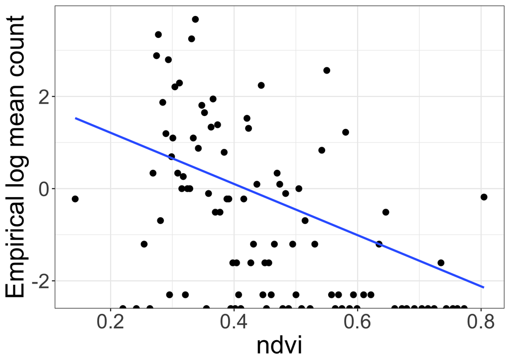

Figure 2.4: The relationship between ndvi and the count of gazelleThomsons over the 8-day period

#### Figure 2.5 gazelleThomsons.count vs. amRivDist

As indicated by Figure 2.5, amRivDist and the log mean of gazelleThomsons.count show up a generally positive linear shape relationship.

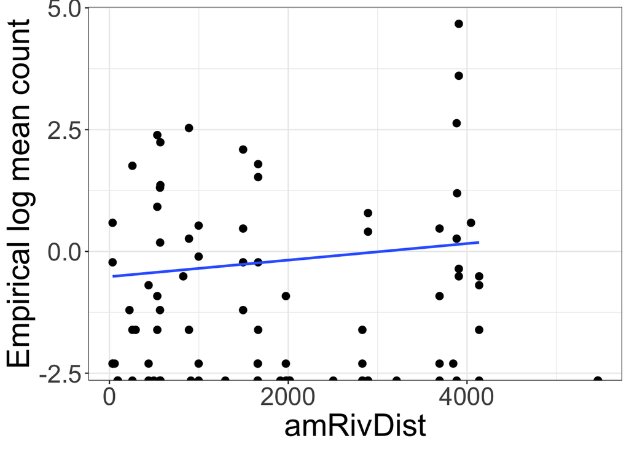

Figure 2.5: The relationship between amRivDist and the count of gazelleThomsons over the 8-day period

#### Figure 2.6 gazelleThomsons.count vs. LriskDry

As indicated by Figure 2.6, LriskDry and the log mean of gazelle Thomsons.count show up a generally positive linear shape relationship.

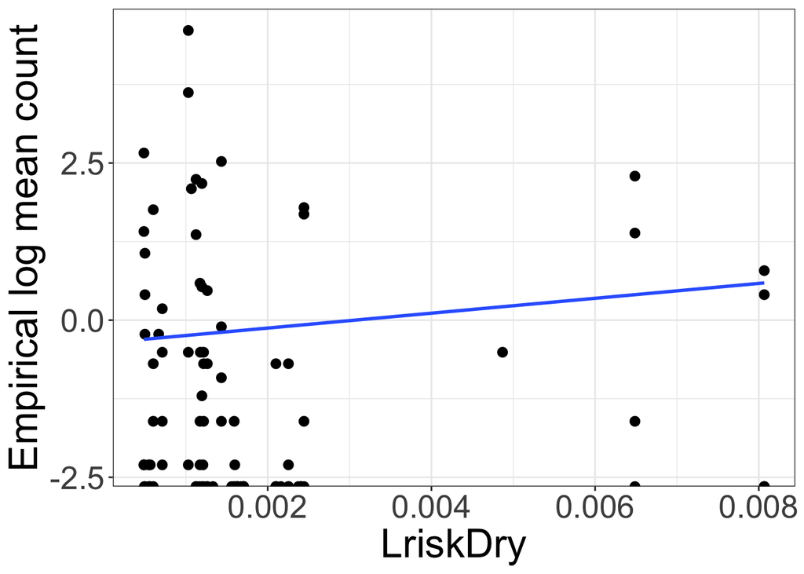

Figure 2.6: The relationship between LriskDry and the count of gazelleThomsons over the 8-day period

#### Figure 2.7 topi.count vs. ndvi

Figure2.7 indicates the relationship between ndvi and the count of topi over the 8-day period, with ndvi on the x-axis and log mean of topi.count on the y-axis. As shown from the figure, the log mean of topi.count shows up a generally positive linear relationship with ndvi. The relationship is not too obvious, the coeficient for the slope should be relatively small.

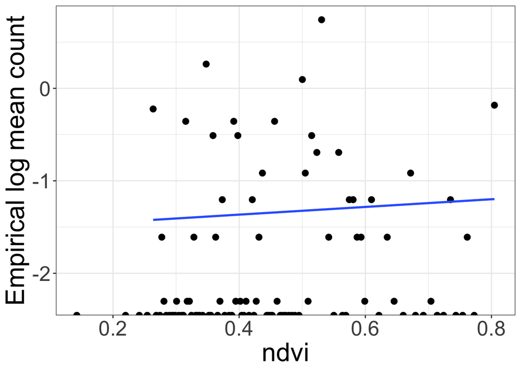

Figure 2.7: The relationship between ndvi and the count of topi over the 8-day period

#### Figure 2.8 topi.count vs. amRivDist

As shown from Figure 2.8, a linear relationship between amRivDist and topi.count looks reasonable, so we conclude that there is a generally negative relationship between amRivDist and topi.count.

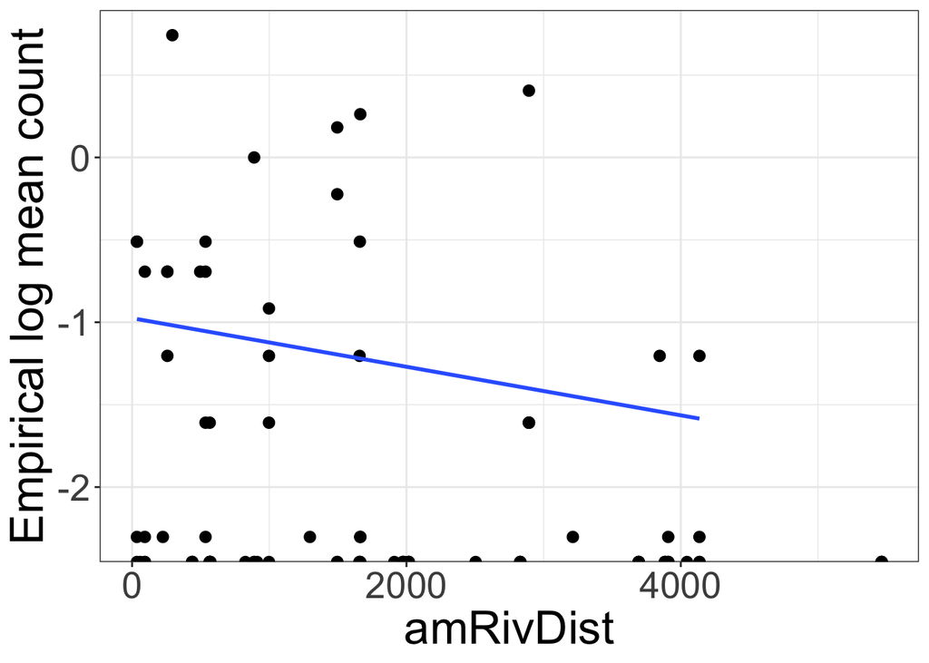

Figure 2.8: The relationship between amRivDist and the count of topi over the 8-day period

#### Figure 2.9 topi.count vs. LriskDry

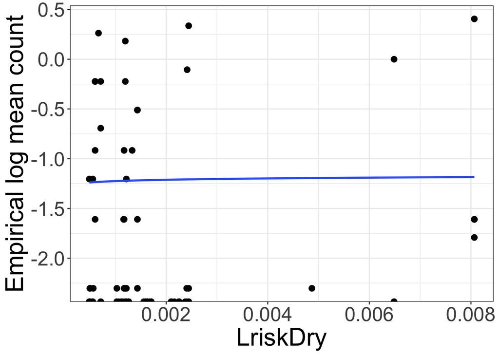

Figure 2.9: The relationship between LriskDry and the count of topi over the 8-day period

#### Figure 2.10 zebra.count vs. ndvi

Indicated by Figure2.10, we applied the second order polynomial transformation to the variable ndvi to rationalize the its relationship with the log mean of zebra.count.

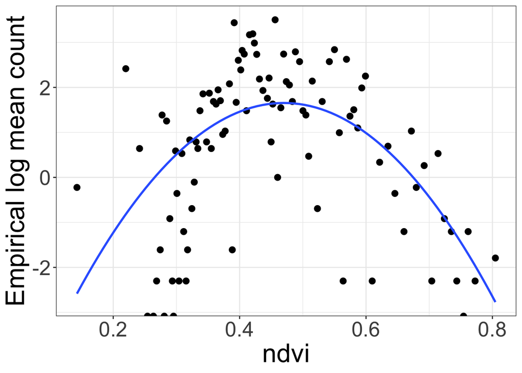

Figure 2.10: The relationship between ndvi and the count of zebra over the 8-day period

#### Figure 2.11 zebra.count vs. amRivDist

As indicated by Figure2.11, there is slightly a negative relationship between amRivDist and zebra.count. We can testify that in the later relationship.

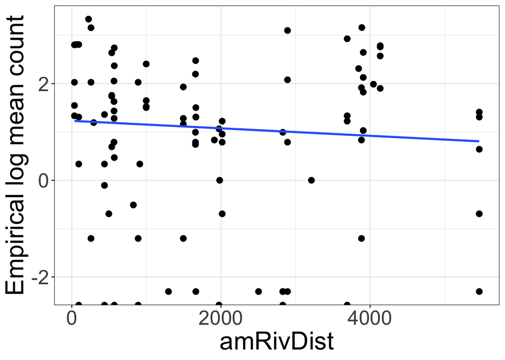

Figure 2.11: The relationship between amRivDist and the count of zebra over the 8-day period

#### Figure 2.12 zebra.count vs. LriskDry

From Figure 2.12, the log mean of zebra.count and LriskDry shows a negative linear relationship. But as the point mainly gathered at the left side of the Figure, the relationship can not be easily defined. So we will testify the relation further in the later hypothesis test.

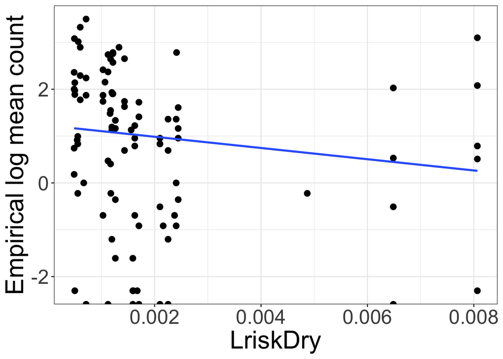

Figure 2.12: The relationship between LriskDry and the count of zebra over the 8-day period

### Section 3: Modeling

### Section 3.1 Importance of Environmental Variables.

As what we observed in EDA on the three response variables, there are excess zeros in the data. In order to build models where we can independently analyzed these ecxess zeros, we use ZIP models.

We will break this section into three parts where part A we build model on gazelleThomsons.count, and part B we build modell on topi.count, and part C we build model on zebra.count.

#### Part A Model on gazelleThomsons.count

$$P(Y_{gazelleThomson}=y)=
\{^{e^{-\lambda_gazelleThomson}(1-\alpha_{gazelleThomson})+\alpha_{gazelleThonson}
\ y =
0}_{\frac{e^{-\lambda_{gazelleThomson}}\lambda_{gazelleThomson}^y}{y!}(1-a_{gazelleThomson})
\ y = 0}$$

$$Y_{gazelleThomson} \ represents \ the \
count \ of \ gazelleThomson \ over \ the \ 8 \ day \ time \ period.$$

$$\lambda_{gazelleThomsons} = average \
number \ of \ gazelleThomsons\ over\ the \ 8\ day \ time \ period.$$

$$a_{gazelleThomsons} = probability \ the
\ gazelleThomsons \ were \ never\ present \ in \ this \ site.$$

There are two parts of the ZIP model: the logistic regression model and the poisson model.From EDA, we already knew that gazelleThomsons.count has linear relationship with ndvi, amRivDist, LriskDry.And we consider ndvi, amRivDist, and LriskDry to be significant variables handling the excess zeros. Therefore, we add these factors and built model A1.

Except continuous quantitative variables, we also have other discrete and categorical variables in the dataset, so we need to add them into the model. However, as we glimpse through these variable T50, TM100, fire, we found out that are bunch of zeros in these three variables, which may have possibility to affect the performance of the fitted model, we will only add TM100 into modelA2 and perform further evaluation on T50 and fire in modelA3 and modelA4.

Further, we also believe that T50, TM100, and fire might be also reasonable variables to be considered affecting the probability of gazelleThomsons never being present at a specific site. Therefore, in modelA5, we add these three variables into the logistic regression model.

#### Population Model of ModelA1 to ModelA4.

$$ModelA1:
log\dfrac{\alpha_{gazelleThomson}}{1-\alpha_{gazelleThomson}} = \gamma_0
+\gamma_1 ndvi +\gamma_2amRivDist +\gamma_3LriskDry \\
log(\lambda_{gazelleThomson}) = \beta_0 + \beta_1 ndvi + \beta_2
amRivDist +\beta_3 LriskDry$$

$$ModelA2:
log\dfrac{\alpha_{gazelleThomson}}{1-\alpha_{gazelleThomson}} = \gamma_0
+\gamma_1 ndvi +\gamma_2amRivDist +\gamma_3LriskDry \\
log(\lambda_{gazelleThomson}) = \beta_0 + \beta_1 ndvi + \beta_2
amRivDist +\beta_3 LriskDry + \beta_4 TM100$$

After fitting the model, we performed hypothesis test between ModelA1 and ModelA2. The drop in deviance G = 2logL(ModelA2)-2logL(Model1) = 2(-2980-(-2980)) = 0. There is no improvements in the model performance. Therefore, we will keep choice with ModelA1.

$$ModelA3:
log\dfrac{\alpha_{gazelleThomson}}{1-\alpha_{gazelleThomson}} = \gamma_0
+\gamma_1 ndvi +\gamma_2amRivDist +\gamma_3LriskDry \\
log(\lambda_{gazelleThomson}) = \beta_0 + \beta_1 ndvi + \beta_2
amRivDist +\beta_3 LriskDry + \beta_4 T50$$

Just as we did between ModelA1 and ModelA2, after fitting ModelA3, we performed hypothesis test between ModelA2 and ModelA3. The drop in deviance G = 2logL(ModelA3)-2logL(ModelA1) = 2(-2878-(-2980)) = 204. G follows a chi-squared distribution with degrees freedom of 1. The probability after performing the hypothesis test is is 2.798881e-46. We therefore have strong evidence that T50 is a valid variable adding into the model. We will then build ModelA4 by adding new variable fire into ModelA3.

$$ModelA4:
log\dfrac{\alpha_{gazelleThomson}}{1-\alpha_{gazelleThomson}} = \gamma_0
+\gamma_1 ndvi +\gamma_2amRivDist +\gamma_3LriskDry \\
log(\lambda_{gazelleThomson}) = \beta_0 + \beta_1 ndvi + \beta_2
amRivDist +\beta_3 LriskDry + \beta_4 T50 + \beta_5 fire$$

$$ModelA5:
log\dfrac{\alpha_{gazelleThomson}}{1-\alpha_{gazelleThomson}} = \gamma_0
+\gamma_1 ndvi +\gamma_2 amRivDist +\gamma_3 LriskDry + \gamma_4 TM100 +
\gamma_5 T50 + \gamma_6 fire \\ log(\lambda_{gazelleThomson}) = \beta_0
+ \beta_1 ndvi + \beta_2 amRivDist +\beta_3 LriskDry + \beta_4 T50 +
+\beta_5 fire$$

The probability of getting the drop in deviance 4 if ModelA3 is more significant is 0.1353353. We therefore will still choose ModelA4 as our model.

#### Conclusion on gazelleThomsonFinal model:

Our Final model for the response variable gazelleThomsons.count will be:

$$gazelleThomsonFinal:
log\dfrac{\alpha_{gazelleThomson}}{1-\alpha_{gazelleThomson}} = -0.3900
+5.162 ndvi -0.00008381amRivDist +0.3286LriskDry \\
log(\lambda_{gazelleThomson}) = 3.081 -2.969 ndvi + 0.0004118 amRivDist
-0.6517 LriskDry -0.002676T50 + 0.5012 fire$$

ndvi, LriskDry have a positive relationship with the count of gazelleThomson over the 8 day time period to be 0, while amRivDist has a negative relationship. And the log mean of the count of gazelleThomson over the day time period is positively associated with RivDist (the distance from the site to the nearest river) and fire (the presence of wildfire over the past 30 days in the site ), and is negatively associated with ndvi(the ‘greenness’ of the site) and LriskDry(the risk of lion predation), T50(the number of trees within 50 meters of the location). Specifically, ndvi, LriskDry, and fire impact the log mean of gazelleThomsons.count the most.

#### Part B Model on topi.count

$$P(Y_{topi}=y)=
\{^{e^{-\lambda_topi}(1-\alpha_{topi})+\alpha_{topi} \ y =
0}_{\frac{e^{-\lambda_{topi}}\lambda_{topi}^y}{y!}(1-a_{topi}) \ y =
0}$$

$$Y_{topi} \ represents \ the \ count \
of \ topi \ over \ the \ 8 \ day \ time \ period.$$

$$\lambda_{topi} = average \ number \ of
\ topi\ over\ the \ 8\ day \ time \ period.$$

$$a_{topi} = probability \ the \ topi \
were \ never\ present \ in \ this \ site.$$

#### Population Model of ModelB1 to ModelB5.

$$ModelB1:
log\dfrac{\alpha_{topi}}{1-\alpha_{topi}} = \gamma_0 +\gamma_1 amRivDist
+ \gamma_2log(LriskDry) \\ log(\lambda_{topi}) = \beta_0 + \beta_1
amRivDist +\beta_2 log(LriskDry)$$

$$ModelB2:
log\dfrac{\alpha_{topi}}{1-\alpha_{topi}} = \gamma_0 +\gamma_1 ndvi
+\gamma_2 amRivDist +\gamma_3 log(LriskDry) \\ log(\lambda_{topi}) =
\beta_0 + \beta_1 ndvi + \beta_2 amRivDist +\beta_3 log(LriskDry)$$

$$ModelB3:
log\dfrac{\alpha_{topi}}{1-\alpha_{topi}} = \gamma_0 +\gamma_1 amRivDist
+ \gamma_2log(LriskDry) \\ log(\lambda_{topi}) = \beta_0 + \beta_2
amRivDist +\beta_3 log(LriskDry) + TM100$$

$$ModelB4:
log\dfrac{\alpha_{topi}}{1-\alpha_{topi}} = \gamma_0 +\gamma_1 amRivDist
+ \gamma_2log(LriskDry) \\ log(\lambda_{topi}) = \beta_0 + \beta_2
amRivDist +\beta_3 log(LriskDry) + T50$$

$$ModelB5:
log\dfrac{\alpha_{topi}}{1-\alpha_{topi}} = \gamma_0 +\gamma_1 amRivDist
+ \gamma_2log(LriskDry) \\ log(\lambda_{topi}) = \beta_0 + \beta_2
amRivDist +\beta_3 log(LriskDry) + fire$$

#### Part C Model on zebra.count

$$P(Y_{zebra}=y)=
\{^{e^{-\lambda_{zebra}}(1-\alpha_{zebra})+\alpha_{zebra} \ y =
0}_{\frac{e^{-\lambda_{zebra}}\lambda_{zebra}^y}{y!}(1-a_{zebra}) \ y =
0}$$

$$Y_{zebra} \ represents \ the \ count \
of \ zebra \ over \ the \ 8 \ day \ time \ period.$$

$$\lambda_{zebra} = average \ number \ of
\ zebra \ over\ the \ 8\ day \ time \ period.$$

$$a_{zebra} = probability \ the \ zebra
\ were \ never\ present \ in \ this \ site.$$

From EDA, we applied second degree of polynomial transformation to ndvi, and we also see a seemingly linear relationship between log mean of zebra.count and amRivDist, LriskDry. So we will build ModelC1 with only variable ndvi, and add amRivDist, LriskDry, TM100, T50, and fire consecutively into the different model to testify their statistical significance, and use several other models to test what variables should be put in the logistic regression model.

#### Population Model of ModelC1 to ModelC6.

$$ModelC1:
log\dfrac{\alpha_{zebra}}{1-\alpha_{zebra}} = \gamma_0 +\gamma_1 ndvi \\
log(\lambda_{zebra}) = \beta_0 + \beta_1 ndvi +\beta_2 ndvi^2$$

$$ModelC2:
log\dfrac{\alpha_{zebra}}{1-\alpha_{zebra}} = \gamma_0 +\gamma_1 ndvi \\
log(\lambda_{zebra}) = \beta_0 + \beta_1 ndvi +\beta_2 ndvi^2 +
\beta_3amRivDist$$

We then perform hypothesis test on ModelC1 and ModelC2. The drop in deviance is G = 2logL(ModelC2)-2logL(ModelC1) = 2(-5437-(-5466)) = 58. G follows a chi-squared distribution with degrees freedom of 1.Use G value of 58 and df of 1, we get the probability equals to 2.621178e-14,. Therefore, we have strong evidence that there is a linear relationship between amRivDist and log mean of zebra.count. ModelC2 is chosen over ModelC1. We then build ModelC3 by adding variable LriskDry to ModelC2.

$$ModelC3:
log\dfrac{\alpha_{zebra}}{1-\alpha_{zebra}} = \gamma_0 +\gamma_1 ndvi \\
log(\lambda_{zebra}) = \beta_0 + \beta_1 ndvi +\beta_2 ndvi^2 +
\beta_3amRivDist + \beta_4LriskDry$$

Same as all the previous hypothesis test, we calculate the drop in deviance from ModelC2 to ModelC3. G = 2logL(ModelC3)-2logL(ModelC2) = 2(-5416-(-5437)) = 42.G follows the chi squared distribution with degree freedom of 1. The probability we get is 9.127342e-11. Therefore, we have strong evidence that there is a linear relationship between log mean of zebra.count and LriskDry.

Then, we build and perform hypothesis test on ModelC4, ModelC5, ModelC6 to decide whether to add the discrete variable TM100, T50, and fire into the model.

$$ModelC4:
log\dfrac{\alpha_{zebra}}{1-\alpha_{zebra}} = \gamma_0 +\gamma_1 ndvi \\
log(\lambda_{zebra}) = \beta_0 + \beta_1 ndvi +\beta_2 ndvi^2 +
\beta_3amRivDist + \beta_4LriskDry +TM100$$

G = 2logL(ModelC4)-2logL(ModelC3) = 2(-5386-(-5416)) = 60.It follows chi-squared distribution of 1 degree freedom. The calculated probability is 9.485738e-15. Therefore, there is a relationship between log mean of zebra.count and TM100. We then choose ModelC4 over ModelC3, and add T50 to ModelC4 to build ModelC5.

$$ModelC5:
log\dfrac{\alpha_{zebra}}{1-\alpha_{zebra}} = \gamma_0 +\gamma_1 ndvi \\
log(\lambda_{zebra}) = \beta_0 + \beta_1 ndvi +\beta_2 ndvi^2 +
\beta_3amRivDist + \beta_4LriskDry +TM100 +T50$$

G = 2logL(ModelC5)-2logL(ModelC4) = 2(-5373-(-5386)) = 26.It follows chi-squared distribution of 1 degree freedom. The calculated probability is 3.414174e-07. Therefore, there is a relationship between log mean of zebra.count and T50. We then choose ModelC5 over ModelC4. Finally, we add fire to ModelC5 to test the significance of variable fire.

$$ModelC6:
log\dfrac{\alpha_{zebra}}{1-\alpha_{zebra}} = \gamma_0 +\gamma_1 ndvi \\
log(\lambda_{zebra}) = \beta_0 + \beta_1 ndvi +\beta_2 ndvi^2 +
\beta_3amRivDist + \beta_4LriskDry +TM100 +T50 +fire$$
G = 2logL(ModelC6)-2logL(ModelC5) = 2(-5373-(-5373)) = 0.There is no improvement in the model performance by adding variable fire. Therefore, we will choose ModelC5. And then, we are going to add variables amRivDist, LriskDry, TM100, and T50 into ModelB5 to test whether we should put these variables into the logistic regression model.

$$ModelC7:
log\dfrac{\alpha_{zebra}}{1-\alpha_{zebra}} = \gamma_0 +\gamma_1
ndvi+\gamma_2 amRivDist +\gamma_3 LriskDry +\gamma_4 TM100+\gamma_5 T50
\\ log(\lambda_{zebra}) = \beta_0 + \beta_1 ndvi +\beta_2 ndvi^2 +
\beta_3amRivDist + \beta_4LriskDry +TM100 +T50$$

G = 2logL(ModelC7)-2logL(ModelC6) = 2(-5363-(-5373)) = 20.G follows the chi squared distribution of degree freedom 4. The probability statistic is 0.0004993992, which is smaller than 0.005. Therefore,we will add these variables into the logistic regression model, and our final model should be ModelC7.

#### Conclusion on zebraFinal model:

```r
pchisq(20, 4,lower.tail = FALSE)
```

```
## [1] 0.0004993992
```

#### Interpretation on the relevant coefficient:

#### A. gazelleThomson

$$gazelleThomsonFinal:
log\dfrac{\alpha_{gazelleThomson}}{1-\alpha_{gazelleThomson}} = -0.3900
+5.162 ndvi -0.00008381amRivDist +0.3286LriskDry \\
log(\lambda_{gazelleThomson}) = 3.081 -2.969 ndvi + 0.0004118 amRivDist
-0.6517 LriskDry -0.002676T50 + 0.5012 fire$$

#### logistic Regression Model - ndvi:

##### coefficient : 5.162

For every unit increase in ndvi, the odds of gazelleThomsons never being present in the site is e^5.162 times higher for the site.

#### amRivDist:

##### coefficient : -0.00008381

For every unit increase in amRivDist, the odds of gazelleThomsons never being present in the site is e^0.00008381 times lower for the site.

#### lriskDry:

##### coefficient : 0.3286

For every unit increase in LriskDry, the odds of gazelleThomsons never being present in the site is e^0.3286 times higher for the site.

#### Poisson Regression - ndvi

##### coefficient : -2.969

Among sites that have gazelleThomsons present before, for every unit increase in the ‘greenness’ of the site,the expected number of count of gazelleThomsons is lowered by a factor of e^2.969 , holding other variables constant.

#### amRivDist

##### coefficient : 0.0004118

Among sites that have gazelleThomsons present before, for every unit increase in the distance from the site to that nearest river, the expected number of count of gazelleThomsons is increased by a factor of e^0.0004118, holding other variables constant.

#### LriskDry

##### coefficient : -0.6517

Among sites that have gazelleThomsons present before, for every unit increase in the risk of lion predation, the expected number of count of gazelleThomsons is lowered by a e^0.6517 , holding other variables constant.

#### T50

##### coefficient : -0.002676

Among sites that have gazelleThomsons present before, for every unit increase in the number of trees within 50 meters of the site, the expected number of count of gazelleThomsons is lowered by a factor of e^0.002676, holding other variables constant.

#### fire

##### coefficient : 0.5012

Among sites that have gazelleThomsons present before, the expected number of count of gazelleThomsons is e^0.5012 times higher for the site has detected wildfire in the past 30 days, holding other variables constant.

$$topiFinal:
log\dfrac{\alpha_{topi}}{1-\alpha_{topi}} = 1.2399062
+0.0002155amRivDist -0.1365214 log(LriskDry) \\ log(\lambda_{topi}) =
2.517228 -0.000266 amRivDist + 0.203947 log(LriskDry)$$

#### poisson Regression - amRivDist

##### coefficient: -0.000266

Among sites that have topi present before, for every unit increase in the distance from the site to that nearest river, the expected number of count of topi is decreased by a factor of e^0.000266, holding other variables constant.

#### LriskDry

##### coefficient : 0.203947

Among sites that have topi present before, for every unit increase in the log risk of lion predation, the expected number of count of topi is increased by a e^0.203947, holding other variables constant.

$$zebraFinal:
log\dfrac{\alpha_{zebra}}{1-\alpha_{zebra}} = 0.4317
-0.01434ndvi+0.00005262amRivDist +0.7283 LriskDry \\+0.2101
TM100-0.001077 T50 \\ log(\lambda_{zebra}) = -3.342 + 0.2789 ndvi
-0.3080 ndvi^2 + 0.00008309amRivDist \\-0.4423LriskDry -0.2336TM100
+0.0003457T50$$

#### T50

##### coefficient : 0.2789

Among sites that have zebra present before, for every unit increase in the ‘greenness’ of the site,the expected number of count of zebra is increased by a factor of e^0.2789, holding other variables constant.

#### ndvi^2

##### coefficient : -0.3080

Among sites that have zebra present before, for every unit increase in ndvi^2 of the site,the expected number of count of zebra is decreased by a factor of e^0.3080, holding other variables constant.

#### TM100

##### coefficient : -0.2336

Among sites that have zebra present before, for every unit increase in the number of termite mounds within 100 meters of the location, the expected number of count of zebra is lowered by a e^0.0.2336, holding other variables constant.

#### T50

##### coefficient : 0.0003457T50

Among sites that have zebra present before, for every unit increase in the number of trees within 50 meters of the site, the expected number of count of zebra is increased by a factor of e^0.0003457T50, holding other variables constant.

### Section 3.2 Comparing species

$$gazelleThomsonFinal:
log\dfrac{\alpha_{gazelleThomson}}{1-\alpha_{gazelleThomson}} = -0.3900
+5.162 ndvi -0.00008381amRivDist +0.3286LriskDry \\
log(\lambda_{gazelleThomson}) = 3.081 -2.969 ndvi + 0.0004118 amRivDist
-0.6517 LriskDry -0.002676T50 + 0.5012 fire$$

$$topiFinal:
log\dfrac{\alpha_{topi}}{1-\alpha_{topi}} = 1.2399062
+0.0002155amRivDist -0.1365214 log(LriskDry) \\ log(\lambda_{topi}) =
2.517228 -0.000266 amRivDist + 0.203947 log(LriskDry)$$

### Section 4 Discussion

Environmental factors definitely have some relationship with the number of species count in one location. And according to our analysis, the counts of these three species - gazelle Thomsons, topi, and zebra are impacted by different environmental variables with different coefficient. For some variables, they even give an opposite correlation. For example, ndvi is positively related to the counts of zebra but it is negatively related to the counts of gazelleThomsons. To find out the reason that explains the difference, we may need to consider add in more data to see whether the result is an occasion.

As we view through the subset data, the value of the species count is relatively small, which makes the analysis hard in some way. So in the further study, we can probably increase the observing time period, and add in more environmental variables to improve the performance of the model.